# Activity 5: Intro to data visualization

Heather Kropp

#### *GEOG 331: Environmental Data Science, Colgate University*

## Instructions

There are 10 questions to this activity. Save your answers in word document that you will hand in on Moodle using a .pdf extension. Keep your script file in your GitHub folder and make sure that all changes are pushed to GitHub. Code for all questions should be clearly commented with the question number. You will include a link to your script file as a part of your final question in this activity. The assignment is worth 30 points.

## Learning objectives

#### 1. Learn about a common type of hydrological data

#### 2. Make different types of visualizations

## Introduction to hydrological data: streamflow and hydrographs

Streamflow is the measurement of how much water is flowing in a river at a moment in time. Measurements of streamflow are useful for a wide variety of applications. Hydrologists at the National Weather Service use these measurements to help forecast floods. The Federal Emergency Management Agency also uses these measurements to predict areas that are prone to flooding. Water managers use streamflow measurements to determine water availability for the public water supply. Finally, streamflow is a critical component in water quality monitoring since the amount and movement of contaminants will depend on the volume and timing of water flow. To understand the nature of these measurements, take a look below at the diagram from USGS documentation found in the data folder: *How Streamflow is measured.pdf*. Both the area of the river (dependent on height of water) and the velocity of the flowing water.

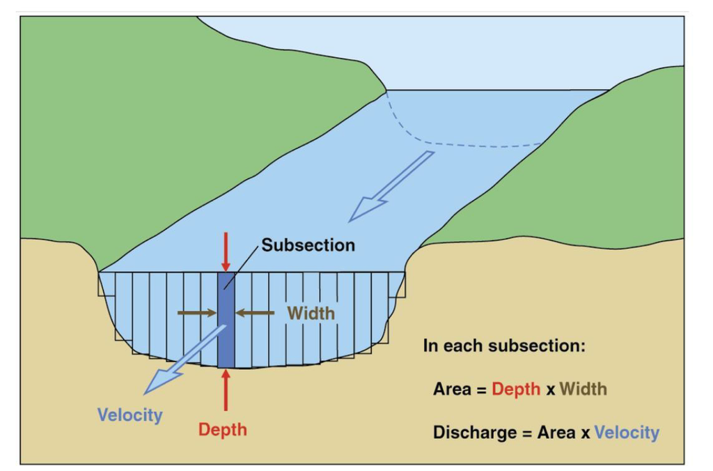

*Source: USGS*

Read through this pdf to better understand the how streamflow is measured. You’ll see that there are many ways to measure flow and some involve using a known relationship with the height of the river and discharge. In this activity, we’ll focus only on discharge (there are some river stage heights in the data too). A graph of the streamflow at a point in a river throughout time is called a **hydrograph**. However, looking at a hydrograph specifically around rainfall events can help characterize the role of rainfall in river flow and predict characteristics related to flooding. Hydrographs typically show a distinctive peak in discharge following a rainfall event. The duration, magnitude, and shape of the hydrograph peak depend on the amount and duration of rain, the shape of the stream, vegetation, land surface characterstics, and human infrastructure. The components of a hydrograph are shown in the graphic below.

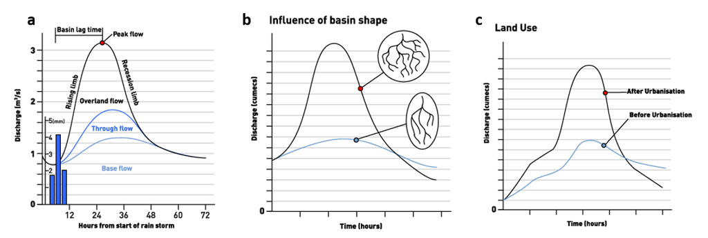

*Source: BBC Geography*

In figure a, a typical hydrograph is shown in the black line (with different components of flow shown in blue) and hydrologists are often interested in the peak flow and lag time between rain and peak flow. Overland flow is another term for runoff. This is all of the water that moves over the land surface and ultimately flows into the stream basin. Figures b and c indicate the effects of basin shape and land use on the shape of the hydrograph. In this activity you will work on data visualizations. For more reference, you can find a cool visualization in the following link from the USGS vizlab that also the role that stream gauges in tracking the flooding following Hurricane Maria (https://owi.usgs.gov/vizlab/hurricane-maria/).

## Working with USGS streamflow data

For this exercise, we’ll work with stream flow data collected in Harbor Brook at Syracuse NY. On the image below, the farthest right image shows an image of the gauging station (where data is collected and saved) with the stream to the left of the station. I’ve included the location on google maps (orange dot and pin) for more context.

[figure not shown]

Below is the site description provided from the USGS. It provides even more information about some of the characteristics that will affect flow in this location.

[figure not shown]

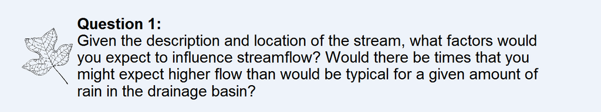

Now let’s read in the data *stream_flow_data.csv*. Note that the file *nwis.waterdata.usgs.gov_readme.text* contains the metadata for the streamflow measurements.Note that this file will mark NAs due to equipment failure with the “Eqp” characters. Load the *lubridate* package for working with dates.

```r
#load in lubridate
library(lubridate)
#read in streamflow data
datH <- read.csv("y:\\Data\\activities\\a05\\stream_flow_data.csv",
                na.strings = c("Eqp"))
head(datH)
```

```
##   agency_cd site_no     date time  tz discharge discharge.flag stage stage.flag
## 1      USGS 4240100 1/1/2007 0:00 EST        14         A:[91]    NA
## 2      USGS 4240100 1/1/2007 0:15 EST        15         A:[91]    NA
## 3      USGS 4240100 1/1/2007 0:30 EST        15         A:[91]    NA
## 4      USGS 4240100 1/1/2007 0:45 EST        14         A:[91]    NA
## 5      USGS 4240100 1/1/2007 1:00 EST        14         A:[91]    NA
## 6      USGS 4240100 1/1/2007 1:15 EST        14         A:[91]    NA
```

```r
#read in precipitation data
#hourly precipitation is in mm
datP <- read.csv("y:\\Data\\activities\\a05\\2049867.csv")
head(datP)
```

```
##       STATION                                 STATION_NAME           DATE HPCP
## 1 COOP:308383 SYRACUSE HANCOCK INTERNATIONAL AIRPORT NY US 20070101 00:00 1.27
## 2 COOP:308383 SYRACUSE HANCOCK INTERNATIONAL AIRPORT NY US 20070101 01:00 0.76
## 3 COOP:308383 SYRACUSE HANCOCK INTERNATIONAL AIRPORT NY US 20070101 02:00 0.25
## 4 COOP:308383 SYRACUSE HANCOCK INTERNATIONAL AIRPORT NY US 20070101 03:00 0.00
## 5 COOP:308383 SYRACUSE HANCOCK INTERNATIONAL AIRPORT NY US 20070101 04:00 0.25
## 6 COOP:308383 SYRACUSE HANCOCK INTERNATIONAL AIRPORT NY US 20070101 16:00 0.00
```

If you look in the *nwis.waterdata.usgs.gov_readme.text* file, you will see that the USGS includes a data quality flag (QA/QC at work!). You’ll notice the flag value of A represents Approved for publication – Processing and review completed. Other flags indicate that data was estimated or is provisional. The first step will be to only work with data that meets publication standards. Create a new dataframe using the code below that subsets the data.

```r
#only use most reliable measurements
datD <- datH[datH$discharge.flag == "A",]
```

Next let’s organize the timestamp information for the data so that it is easier to work with for plotting. I find it helpful to convert time to decimal days and decimal day of year for easier control over plot ranges.

```r
#### define time for streamflow #####
#convert date and time
datesD <- as.Date(datD$date, "%m/%d/%Y")
#get day of year
datD$doy <- yday(datesD)
#calculate year
datD$year <- year(datesD)
#define time
timesD <- hm(datD$time)

#### define time for precipitation #####
dateP <- ymd_hm(datP$DATE)
#get day of year
datP$doy <- yday(dateP)
#get year
datP$year <- year(dateP)

#### get decimal formats #####
#convert time from a string to a more usable format
#with a decimal hour
datD$hour <- hour(timesD ) + (minute(timesD )/60)
#get full decimal time
datD$decDay <- datD$doy + (datD$hour/24)
#calculate a decimal year, but account for leap year
datD$decYear <- ifelse(leap_year(datD$year),datD$year + (datD$decDay/366),
                        datD$year + (datD$decDay/365))
#calculate times for datP
datP$hour <- hour(dateP ) + (minute(dateP )/60)
#get full decimal time
datP$decDay <- datP$doy + (datP$hour/24)
#calculate a decimal year, but account for leap year
datP$decYear <- ifelse(leap_year(datP$year),datP$year + (datP$decDay/366),
                        datP$year + (datP$decDay/365))
```

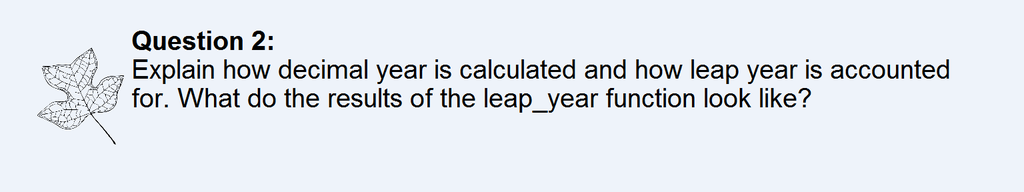

Now that you are familar with the data and organized the dates, let’s start working with visualizations. If you make a quick line plot of the data we’ll notice it can be difficult to make out trends with so much data in this small window.

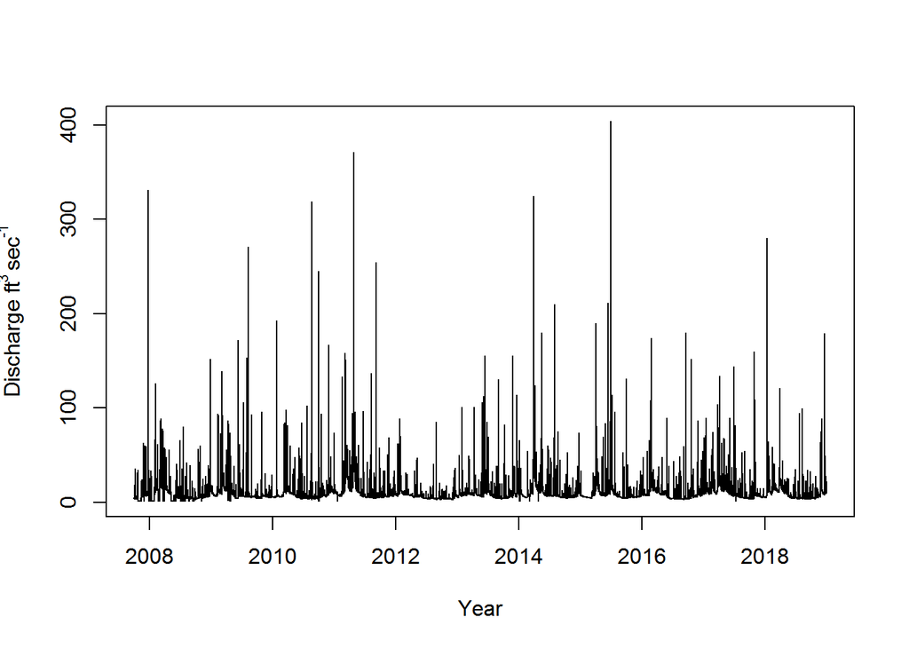

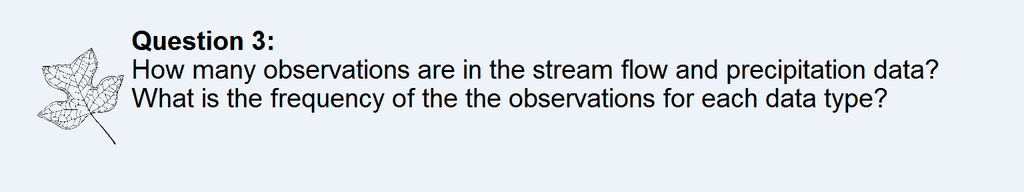

```r
#plot discharge
plot(datD$decYear, datD$discharge, type="l", xlab="Year", ylab=expression(paste("Discharge ft"^"3 ","sec"^"-1")))
```

When you make your plot, resize the plotting window to be really big (your entire screen) and then really small (tiny box).

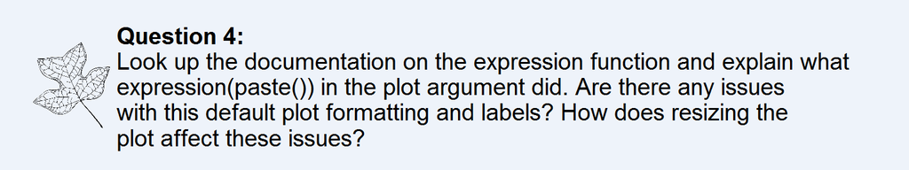

## Basic plot formatting

In this next section you will learn some basic plotting arguments that help with plot formatting. For this example, let’s plot the average daily discharge across all years with the standard deviation for each day. First you’ll need to calculate this average. This will tell us the average discarge on any given day of the year across all measurements.

```r
#basic formatting
aveF <- aggregate(datD$discharge, by=list(datD$doy), FUN="mean")
colnames(aveF) <- c("doy","dailyAve")
sdF <- aggregate(datD$discharge, by=list(datD$doy), FUN="sd")
colnames(sdF) <- c("doy","dailySD")
```

You can improve the plot by using a few plotting arguements. The **dev.new** function will start a new plot window with a standard size. The **par** function contains many arguments for plots. You are familar with it for setting up multiple plots in the same window. You can also change margin size so that the text doesn’t get cut off using the **mai** argument.

```r
#start new plot
dev.new(width=8,height=8)
```

The **par** function contains many arguments for plots. You are familar with it for setting up multiple plots in the same window. You can also change margin size so that the text doesn’t get cut off using the **mai** argument.

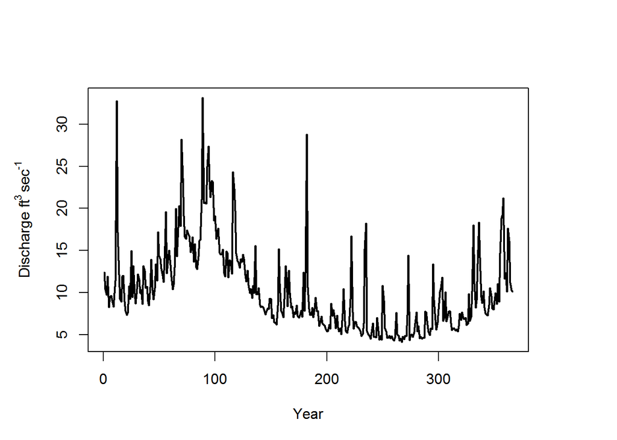

```r
#bigger margins
par(mai=c(1,1,1,1))
#make plot
plot(aveF$doy,aveF$dailyAve,
    type="l",
    xlab="Year",
    ylab=expression(paste("Discharge ft"^"3 ","sec"^"-1")),
    lwd=2)
```

You can add a **polygon** to show the standard deviation interval around lines. You’ll probably want to make the y axis larger in order to fully show the range of the standard deviation. Here your arguments will need to fully encapsulate all coordinates for the range of x and y.You’ll need to use the **rev** to reverse the second set of x coordinates to draw the upper interval of the polygon correctly. It can also be helpful to remove the gaps from the axes. You can do that with the **xaxs** and **yaxs** arguments.

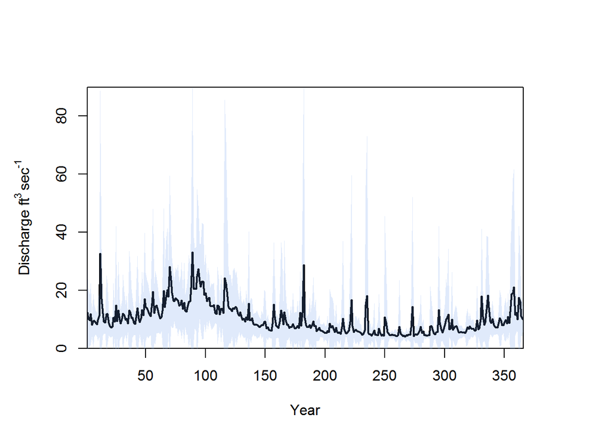

```r
#bigger margins
par(mai=c(1,1,1,1))
#make plot
plot(aveF$doy,aveF$dailyAve,
    type="l",
    xlab="Year",
    ylab=expression(paste("Discharge ft"^"3 ","sec"^"-1")),
    lwd=2,
    ylim=c(0,90),
    xaxs="i", yaxs ="i")#remove gaps from axes
#show standard deviation around the mean
polygon(c(aveF$doy, rev(aveF$doy)),#x coordinates
        c(aveF$dailyAve-sdF$dailySD,rev(aveF$dailyAve+sdF$dailySD)),#ycoord
        col=rgb(0.392, 0.584, 0.929,.2), #color that is semi-transparent
        border=NA#no border
        )
```

You can also adjust the axis display by using the **axis** function and turning off the default axes in the main plot argument. There is an arguments called **las** that also allows you to change the direction of the axis ticks.

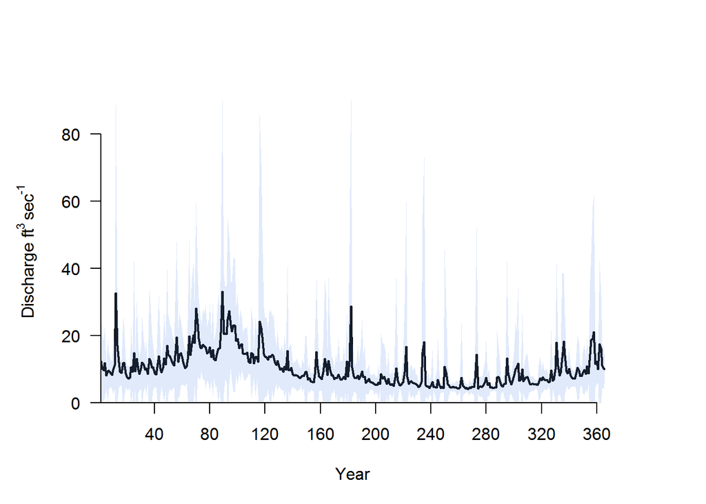

```r
#bigger margins
par(mai=c(1,1,1,1))
#make plot
plot(aveF$doy,aveF$dailyAve,
    type="l",
    xlab="Year",
    ylab=expression(paste("Discharge ft"^"3 ","sec"^"-1")),
    lwd=2,
    ylim=c(0,90),
    xaxs="i", yaxs ="i",#remove gaps from axes
    axes=FALSE)#no axes
polygon(c(aveF$doy, rev(aveF$doy)),#x coordinates
        c(aveF$dailyAve-sdF$dailySD,rev(aveF$dailyAve+sdF$dailySD)),#ycoord
        col=rgb(0.392, 0.584, 0.929,.2), #color that is semi-transparent
        border=NA#no border
        )
axis(1, seq(0,360, by=40), #tick intervals
        lab=seq(0,360, by=40)) #tick labels
axis(2, seq(0,80, by=20),
        seq(0,80, by=20),
        las = 2)#show ticks at 90 degree angle
```

Now let’s add a legend. In the **legend** function, you can add a legend using exact coordinates or specifying a location like “topright” or “center”. You indicate all elements in the legend and items that you want to include.

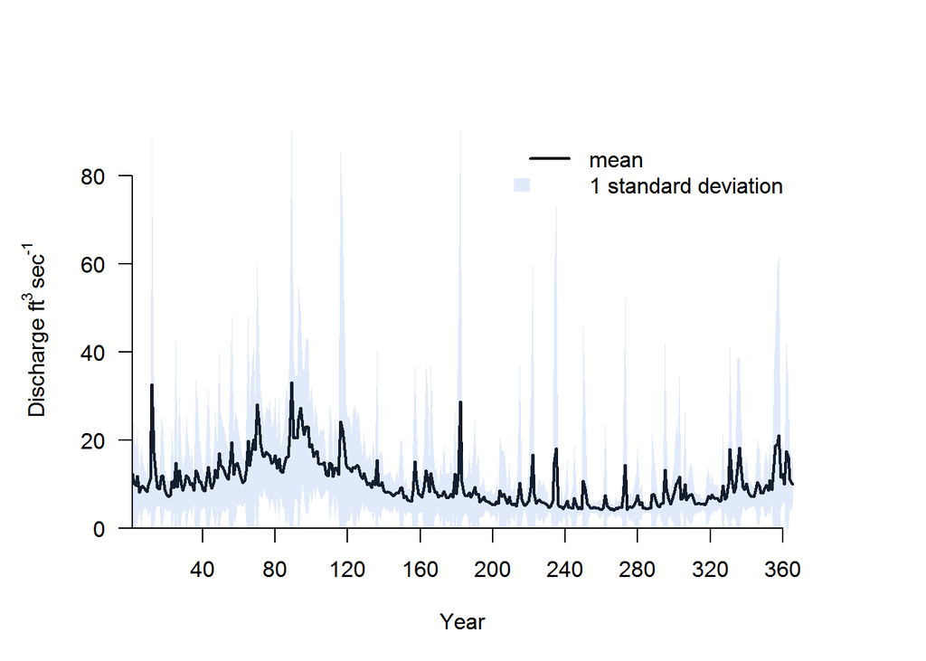

```r
#bigger margins
par(mai=c(1,1,1,1))
#make plot
plot(aveF$doy,aveF$dailyAve,
    type="l",
    xlab="Year",
    ylab=expression(paste("Discharge ft"^"3 ","sec"^"-1")),
    lwd=2,
    ylim=c(0,90),
    xaxs="i", yaxs ="i",#remove gaps from axes
    axes=FALSE)#no axes
polygon(c(aveF$doy, rev(aveF$doy)),#x coordinates
        c(aveF$dailyAve-sdF$dailySD,rev(aveF$dailyAve+sdF$dailySD)),#ycoord
        col=rgb(0.392, 0.584, 0.929,.2), #color that is semi-transparent
        border=NA#no border
        )
axis(1, seq(0,360, by=40), #tick intervals
        lab=seq(0,360, by=40)) #tick labels
axis(2, seq(0,80, by=20),
        seq(0,80, by=20),
        las = 2)#show ticks at 90 degree angle
legend("topright", c("mean","1 standard deviation"), #legend items
                lwd=c(2,NA),#lines
                fill=c(NA,rgb(0.392, 0.584, 0.929,.2)),#fill boxes
                border=NA,#no border for both fill boxes (don't need a vector here since both are the same)
                 bty="n")#no legend border
```

The base R legend can be a little frustrating. You will notice the fill boxes don’t align with the line. I often use a trick that uses a square point rather than a fill box to make sure everything lines up.

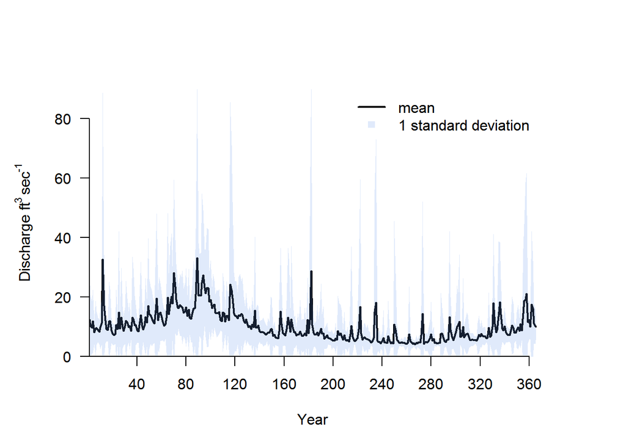

```r
#bigger margins
par(mai=c(1,1,1,1))
#make plot
plot(aveF$doy,aveF$dailyAve,
    type="l",
    xlab="Year",
    ylab=expression(paste("Discharge ft"^"3 ","sec"^"-1")),
    lwd=2,
    ylim=c(0,90),
    xaxs="i", yaxs ="i",#remove gaps from axes
    axes=FALSE)#no axes
polygon(c(aveF$doy, rev(aveF$doy)),#x coordinates
        c(aveF$dailyAve-sdF$dailySD,rev(aveF$dailyAve+sdF$dailySD)),#ycoord
        col=rgb(0.392, 0.584, 0.929,.2), #color that is semi-transparent
        border=NA#no border
        )
axis(1, seq(0,360, by=40), #tick intervals
        lab=seq(0,360, by=40)) #tick labels
axis(2, seq(0,80, by=20),
        seq(0,80, by=20),
        las = 2)#show ticks at 90 degree angle
legend("topright", c("mean","1 standard deviation"), #legend items
                lwd=c(2,NA),#lines
                col=c("black",rgb(0.392, 0.584, 0.929,.2)),#colors
                pch=c(NA,15),#symbols
                 bty="n")#no legend border
```

That looks much better!

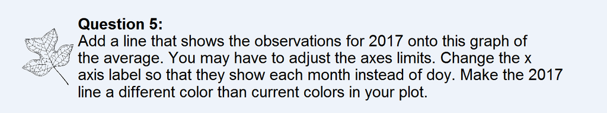

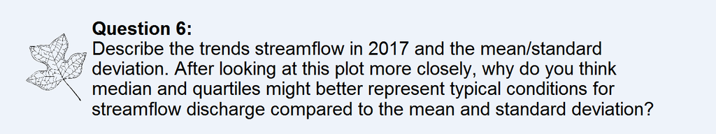

## Making a hydrograph

Let’s make a hydrograph around a rain event. You’ll want to focus on the summer since you don’t have air temperature or information that might indicate whether precipitation is snow. Snow will have a different effect on streamflow since runoff is delayed until melt. You’ll also notice that the precipitation data is very short. Even with the precipitation only collected at the hourly level, the length of the dataframe seems very small. You’ll need to dig deeper into this.

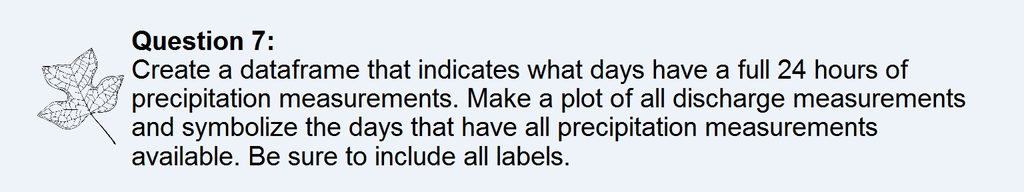

Now let’s learn making a figure with both lines and bars from scratch by making a hydrograph. There are many packages in addition to ggplot2 that can help make this kind of plot. However, having a fundamental understanding of how to do this yourself can help you troubleshoot and better understand the mechanics of making a plot. It’s a useful skill for making simple yet sophisticated figures. First, let’s work with a couple of days because it is hard to see hydrographs over a long time period. We’ll look at September 5 and 6 in 2011. September 5 has a full day of precipitation measurements and I have verified that any missing measurements on the 6 had no precipitation. Let’s subset the precipitation and discharge dataframes to be limited to this period.

```r
#subsest discharge and precipitation within range of interest
hydroD <- datD[datD$doy >= 248 & datD$doy < 250 & datD$year == 2011,]
hydroP <- datP[datP$doy >= 248 & datP$doy < 250 & datP$year == 2011,]
```

You will use the polygon function for making bars for the plot. For making boxes, the polygon function needs to read in all four x coordinates in a vector and all four y coordinates in a vector. Remember that R will want to draw the four coordinates to make a box like below:

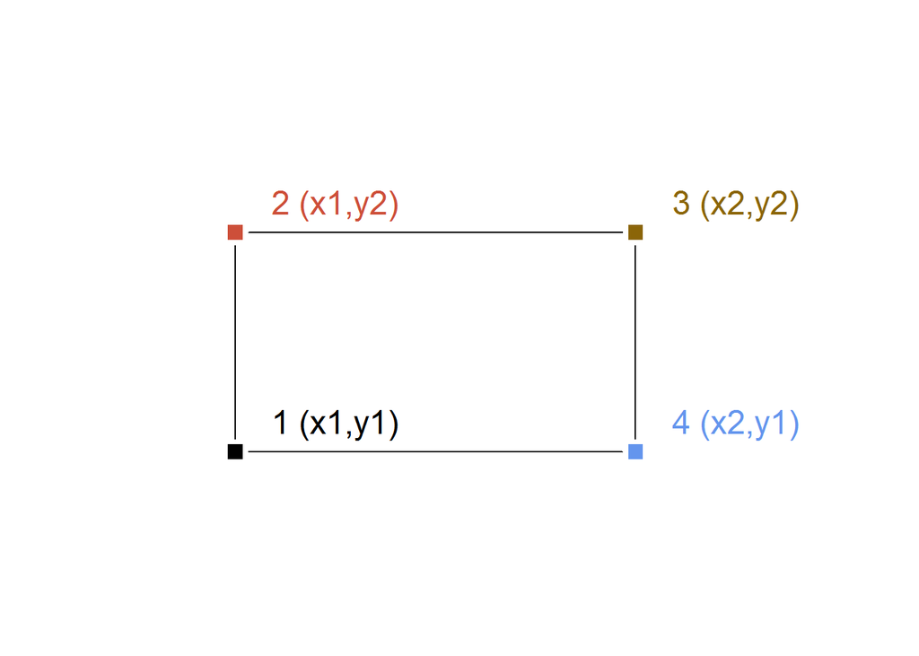

We’ll also have to scale the precipitation values to fit on the discharge plot. In this case, a value of zero on the y axis may not necessarily be meaningful. A value of zero means that the stream has completely dried up and has no flow. There are many streams (especially big rivers) that have a high flow all year long. Displaying a zero may unnecessarily hide variation and make the plot difficult to read. If we look at the minimum value for flow during this period, we’ll see that it is not close to zero.

```r
min(hydroD$discharge)
```

```
## [1] 4.29
```

Since there are periods with no precipitation, we’ll need to make sure we adjust the scaling of our precipitation values to account for a y minimum value not at zero. In the precipitation dataframe, you will create a variable called *pscale* that accounts for these issues.

```r
#get minimum and maximum range of discharge to plot
#go outside of the range so that it's easy to see high/low values
#floor rounds down the integer
yl <- floor(min(hydroD$discharge))-1
#celing rounds up to the integer
yh <- ceiling(max(hydroD$discharge))+1
#minimum and maximum range of precipitation to plot
pl <- 0
pm <-  ceiling(max(hydroP$HPCP))+.5
#scale precipitation to fit on the
hydroP$pscale <- (((yh-yl)/(pm-pl)) * hydroP$HPCP) + yl
```

Now you are ready to make your plot with both points and polygons. You can use the variables you set up in the scaling code above to make your plot.

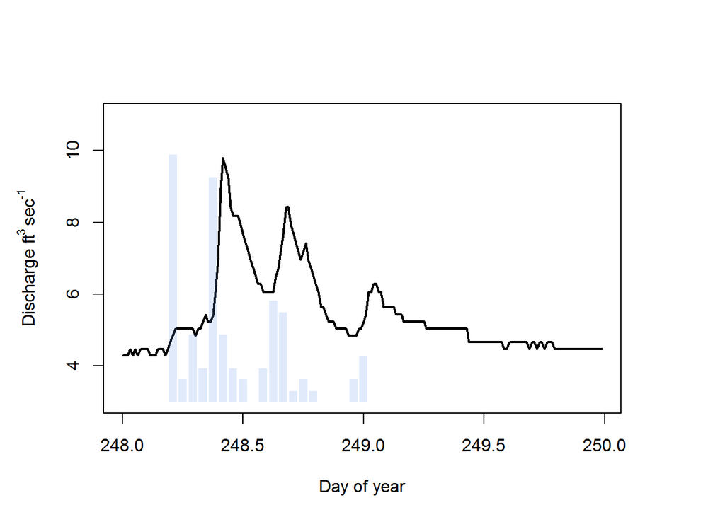

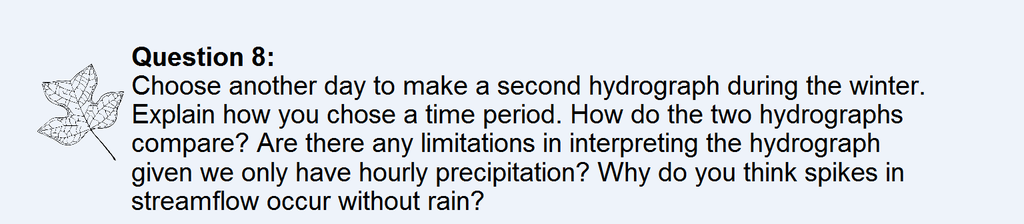

```r
par(mai=c(1,1,1,1))
#make plot of discharge
plot(hydroD$decDay,
    hydroD$discharge,
    type="l",
    ylim=c(yl,yh),
    lwd=2,
    xlab="Day of year",
    ylab=expression(paste("Discharge ft"^"3 ","sec"^"-1")))
#add bars to indicate precipitation
for(i in 1:nrow(hydroP)){
 polygon(c(hydroP$decDay[i]-0.017,hydroP$decDay[i]-0.017,
            hydroP$decDay[i]+0.017,hydroP$decDay[i]+0.017),
        c(yl,hydroP$pscale[i],hydroP$pscale[i],yl),
        col=rgb(0.392, 0.584, 0.929,.2), border=NA)
}
```

Don’t forget you can always find historical daily weather data for a single day if you want to check for a missing data value. You used this resource in Activity 3.

## Making box plots & violin plots

Now let’s explore one last way to make plots. Let’s use ggplot2 to make boxplots and violin plots. Box plots are automatically made in base R when a factor is an x value and the y value is continuous. However, it would be good to get more familar with ggplot2 and you’ll be able to do a violin plot quickly!

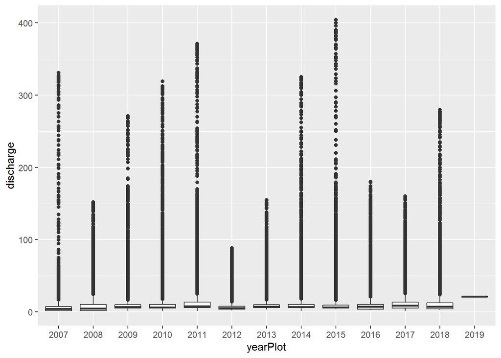

```r
library(ggplot2)
#specify year as a factor
datD$yearPlot <- as.factor(datD$year)
#make a boxplot
ggplot(data= datD, aes(yearPlot,discharge)) +
    geom_boxplot()
```

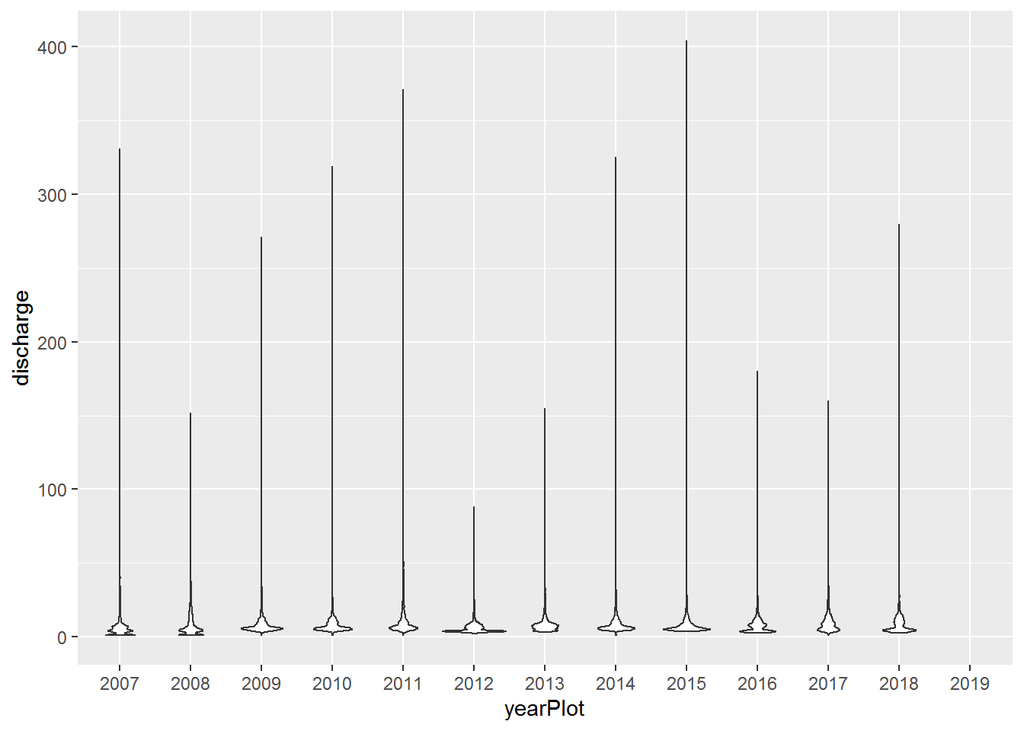

```r
#make a violin plot
ggplot(data= datD, aes(yearPlot,discharge)) +
    geom_violin()
```

These types of plots are very useful for thinking about the variation in data. However, with a dataset like streamflow where low values are common with large spikes in streamflow occuring infrequently they can be harder to visualize.

Let’s take a look at streamflow for 2016 and 2017 by season (winter, spring, summer,fall). You’ll need to look up the calendar definition for these seasons and make a factor variable. Make a violin plot that shows streamflow over these seasons by each year (2016 & 2017 only).

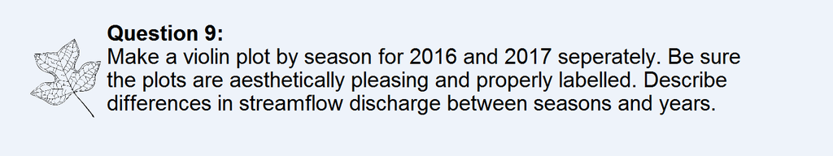

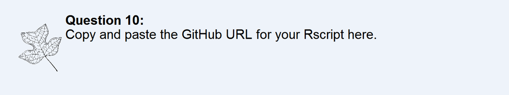